# Лабораторийн ажил 7-8

## Ангилал (Classification)

Дараах заавар нь ангиллын асуудлыг шийдвэрлэх Python жишээг агуулна.  
Ангилал гэдэг нь бусад атрибутын (урьдчилан таамаглах хувьсагч гэгддэг) утгууд дээр үндэслэн нэрлэсэн утгатай атрибутыг (ангиллын шошго гэж нэрлэдэг) таамаглах ажил юм. Энэхүү лабораторийн ажлын хүрээнд:

1. Өөр өөр ангиллын техникүүдийг ашиглаж болох жишээг өгөх.
2. Шийдвэрийн модны ангилагч ашиглах

## Шийдвэрийн мод (Decision tree)

### Давуу тал

- **Ойлгоход хялбар:** Шийдвэрийн модны гаралт нь шинжилгээний талаар мэдлэггүй хүмүүст ч ойлгоход хялбар. Өөрөөр хэлбэл тэдгээрийг унших, тайлбарлахад статистикийн ямар ч мэдлэг шаардагддаггүй. Түүний график дүрслэл нь маш ойлгомжтой бөгөөд хэрэглэгчид өөрсдийн таамаглалыг хялбархан холбож чаддаг.
- **Өгөгдлийн урьдчилсан судалгаанд ашиг тустай:** Шийдвэрийн мод нь хамгийн чухал хувьсагч болон хоёр ба түүнээс дээш хувьсагчийн хоорондын хамаарлыг тодорхойлох хамгийн хурдан арга замуудын нэг юм. Жишээлбэл, олон зуун хувьсагчийн мэдээлэлтэй асуудал дээр шийдвэрийн мод нь хамгийн чухал хувьсагчийг тодорхойлоход тусална.
- **Өгөгдлийн цэвэрлэгээ бага шаардана:** Энэ нь бусад загварчлалын техниктэй харьцуулахад өгөгдлийн цэвэрлэгээг бага шаарддаг. Үүнд хэт давсан үзүүлэлт (outlier), дутуу утга (missing value) зохих хэмжээгээр нөлөөлдөггүй.
- **Өгөгдлийн төрөл нь хязгаарлалт биш:** Энэ нь тоон болон категорийн хувьсагчдыг хоёуланг нь зохицуулж чадна.

## 1. Сээр нуруутан амьтдын өгөгдлийн багц

Сээр нуруутан амьтдын өгөгдлийн багцыг ашиглана. Сээр нуруутан амьтад бүрийг тайлбарлах атрибутууд (урьдчилан таамаглагч хувьсагчдад) үндэслэн хөхтөн амьтад, хэвлээр явагчид, шувууд, загаснууд, хоёр нутагтан амьтад гэсэн 5 ангиллын аль нэгэнд ангилдаг. **"name"**-ээс бусад бусад атрибутуудыг *one hot encoding* хоёртын дүрслэл болгон хувиргасан. Үүнийг харуулахын тулд эхлээд Pandas DataFrame объект руу өгөгдлийг ачаалж, агуулгыг нь харуулах болно.

**one hot encoding**  
Энэ нь категорийн хувьсагчдыг хоёртын (binary) вектор хэлбэрээр илэрхийлэх машин сургалт, өгөгдлийн шинжилгээнд ашигладаг өгөгдлийг дүрслэх арга юм. Энэ техникт категори бүрийг хоёртын утгуудын вектороор төлөөлдөг бөгөөд утга тус бүр нь тодорхой ангилалд нийцдэг. Вектор нь ангилалд тохирох байрлалд 1, бусад бүх байрлалд 0-г агуулна. Энэ нь мэдрэлийн сүлжээ, шийдвэрийн мод зэрэг олон алгоритмд тохирсон байдлаар категори өгөгдлийг дүрслэх боломжийг олгодог.

```python
import pandas as pd

data = pd.read_csv('vertebrate.csv',header='infer')
data
```

Сургалтын жишээнүүдийн тоо хязгаарлагдмал тул асуудлыг хоёртын ангиллын (binary classification) даалгавар болгон хөрвүүлье (хөхтөн амьтад болон хөхтөн бус амьтад). *хөхтөн амьтад* ангилалд хамаарахаас бусад тохиолдлуудын ангиллын шошгыг *хөхтөн бус амьтад* гэж солих байдлаар хоёртын ангилал руу хөрвүүлье.

```python
data['Class'] = data['Class'].replace(['fishes','birds','amphibians','reptiles'],'non-mammals')
data
```

**'Warm-blooded'** болон **'Gives Birth'** атрибутуудын хоорондын хамаарлыг ангилалтай нь уялдуулан шалгахын тулд бид Pandas-н хөндлөн хүснэгтийг (cross-tabulation) ашиглаж болно.

```python
pd.crosstab([data['Warm-blooded'],data['Gives Birth']],data['Class'])
```

[output not shown]

Дээрх үр дүн нь энэ хоёр атрибутыг ашиглан хөхтөн амьтдыг хөхтөн бус амьтнаас ялгах боломжтойг харуулж байна, учир нь тэдгээрийн атрибутын утгуудын хослол бүр нь зөвхөн нэг ангилалд хамаарах тохиолдлуудыг гаргах болно. Жишээ нь, дээрх хүснэгтээ бид хөхтөн амьтдыг үр төлөө төрүүлдэг, халуун цуст сээр нуруутан амьтан гэж тодорхойлж болно. Энэ хамаарлыг дараагийн дэд хэсэгт өгөгдсөн жишээнд үзүүлсэн шиг шийдвэрийн модны ангилагч ашиглан гаргаж болно.

## 2. Шийдвэрийн модны ангилагч (Decision Tree Classifier)

Энэ хэсэгт өмнөх дэд хэсэгт тайлбарласан сээр нуруутан амьтдын өгөгдлийн багцад шийдвэрийн модны ангилагчийг ашиглана.

```python
from sklearn import tree

Y = data['Class']
X = data.drop(['Name','Class'],axis=1)

clf = tree.DecisionTreeClassifier(criterion='entropy',max_depth=3)
clf = clf.fit(X, Y)
```

Өмнөх командууд нь сээр нуруутан амьтдын өгөгдлийн багцаас урьдчилан таамаглагч *(X)* болон зорилтот ангиллын *(Y)* атрибутуудыг гаргаж аваад, хуваах шалгуурын бохирдлын хэмжүүр болгон "*entropy*"-г ашиглан шийдвэрийн модны ангилагч объектыг үүсгэнэ. **Python sklearn** сангийн шийдвэрийн модны класс нь мөн "*gini index*"-г бохирдлын хэмжүүр болгон ашиглахыг дэмждэг. Дээрх ангилагч нь хамгийн их гүн нь 3-тай тэнцүү мод үүсгэхээр хязгаарлагддаг. Дараа нь ангилагчийг *fit()* функцийг ашиглан шошготой өгөгдөл дээр сургадаг.

Бид ангилагчийг сургасны дараа олж авсан шийдвэрийн модыг зурж болно. Үүнийг хийхийн тулд эхлээд *graphviz* (http://www.graphviz.org) болон түүний *pydotplus* (http://pydotplus.readthedocs.io/) нэртэй Python интерфейсийг хоёуланг нь суулгах хэрэгтэй.

*graphviz* суулгахдаа дараах бичлэгийг харна уу.

https://www.youtube.com/watch?v=kOYnlqbZ8K4

pip install pydotplus

*Graphviz* бол үнэгүй, нээлттэй эхийн график дүрслэх програм хангамжийн багц юм. Энэ нь шийдвэрийн мод, сүлжээний диаграм, урсгалын диаграммыг дүрслэн харуулахын тулд машин сургалт, өгөгдлийн шинжилгээнд ихэвчлэн ашиглагддаг.

- **Graphviz** нь графикийн бүтэц, шинж чанарыг тайлбарлахдаа текстэд суурилсан энгийн хэлийг ашигладаг. Энэ хэлийг **DOT** гэж нэрлэдэг бөгөөд энэ нь хэрэглэгчдэд энгийн синтакс ашиглан графикийн зангилаа, ирмэг, шинж чанарыг тодорхойлох боломжийг олгодог. Иймээс энэ процессын эхний хэсэг нь цэг файл үүсгэх явдал юм. Цэг файл нь шийдвэрийн модны график дүрслэл юм. Загвараа цэг файл руу экспортлохын тулд дараах кодыг ашигладаг. Python цэгийн файл үүсгэж, tree.dot нэртэй файл болгон экспортлох үйлдлийг доор харуулсан байна.

```
tree.export_graphviz(clf,
                     out_file="tree.dot",
                     feature_names = fn,
                     class_names=cn,
                     filled = True)
```

- График тодорхойлогдсоны дараа **Graphviz** нь графикийн дүрслэлийг **PNG, SVG, PDF, PostScript** зэрэг янз бүрийн форматаар үүсгэж болно. Иймээс цэг файлыг зургийн файл (png, jpg гэх мэт) болгон хөрвүүлэх хэрэгтэй. **PyDotPlus** нь **Graphviz**-ийн **DOT** хэлний **Python** интерфейс юм. Өөрөөр хэлбэл **DOT** файлыг **Pydotplus**-ээр дамжуулан **Graphviz** ашиглан **PNG** зураг болгон гаргах боломжтой.

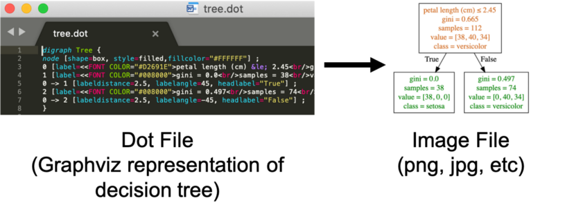

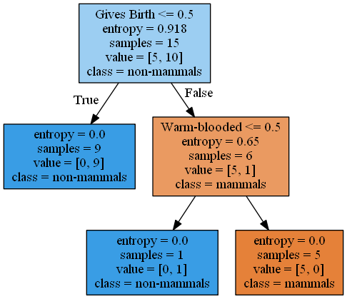

```python
import pydotplus
from IPython.display import Image

#dot_data = tree.export_graphviz(clf, feature_names=X.columns, class_names=['mammals','non-mammals'], filled=True, out_file=None)
dot_data = tree.export_graphviz(clf, feature_names=X.columns, class_names=Y, filled=True, out_file=None)
graph = pydotplus.graph_from_dot_data(dot_data)
Image(graph.create_png())
```

Дараах тестийн жишээнүүдийг ангилахын тулд шийдвэрийн модыг ашиглая.

```python
testData = [['gila monster',0,0,0,0,1,1,'non-mammals'],
           ['platypus',1,0,0,0,1,1,'mammals'],
           ['owl',1,0,0,1,1,0,'non-mammals'],
           ['dolphin',1,1,1,0,0,0,'mammals']]
testData = pd.DataFrame(testData, columns=data.columns)
testData
```

Эхлээд тестийн өгөгдлөөс урьдчилан таамаглагч болон зорилтот ангиллын атрибутуудыг гаргаж аваад ангиллыг нь таамаглахын тулд шийдвэрийн модны ангилагчийг (decision tree classifier) ашиглана.

```python
testY = testData['Class']
testX = testData.drop(['Name','Class'],axis=1)

predY = clf.predict(testX)
print(predY)
predictions = pd.concat([testData['Name'],pd.Series(predY,name='Predicted Class')], axis=1)
predictions
```

[output not shown]

Өндөглөдөг хөхтөн амьтан болох **platypus**-с бусад тохиолдолд ангилагч нь тестийн жишээнүүдийн ангиллын шошгыг зөв таамагласан байна. Тестийн өгөгдөл дээрх ангилагчийн нарийвчлалыг доор үзүүлсэн жишээгээр тооцоолж болно.

```python
from sklearn.metrics import accuracy_score

print('Accuracy on test data is %.2f' % (accuracy_score(testY, predY)))
```

[output not shown]

## Даалгавар

**car.csv** өгөгдлийг ашиглан хийх даалгавар. Энэхүү өгөгдөл нь машины үнэлгээтэй холбоотой дараах утгуудыг агуулсан.

- Машины үнэ
  - Худалдан авах үнэ
  - Засвар үйлчилгээний үндсэн үнэ
- Техникийн шинж чанар
  - Хаалганы тоо
  - Хүний багтаамж
  - Ачааны хэсгийн хэмжээ
- Машины аюулгүй байдал
  - Аюулгүй байдал

Шийдвэрийн модны ангилагч байгуулах үед ашиглах атрибутууд категор төрлийн байгаа эсэхийг нягтална уу.

**Ангиллын шошго**  
unacc, acc, good, vgood

**Атрибутууд**  
*buying*: vhigh, high, med, low  
*maint*: vhigh, high, med, low  
*doors*: 2, 3, 4, 5more  
*persons*: 2, 4, more  
*lug_boot*: small, med, big  
*safety*: low, med, high

1. Өгөгдлийн эхний 5 бичлэгийг хэвлэ.
2. Давхцсан мөр байгаа эсэхийг шалгаж, байгаа бол устга.
3. Дутуу утга /Missing value/ байгаа эсэхийг шалга.
4. Өгөгдлийн багцаас урьдчилан таамаглагч **(X)** болон зорилтот ангиллын **(Y)** шинж чанаруудыг гаргаж ав.
5. Урьдчилан таамаглагч **(X)** багцын категорийн атрибутуудыг кодлохдоо **Тэмдэглэл-1** дагуу хийнэ үү. Эхний 5 бичлэгийг хэвлэж хар.
6. Өгөгдлийг сургалтын (training set) болон тестийн багц (test set) болгон хуваа. **X_train** болон **X_test** -н хэлбэрийг хэвлэж хар. **Тэмдэглэл-2** харна уу.
7. 6-р алхмыг хийж дуусахад, сургалт болон туршилтын багц загварыг байгуулахад бэлэн болно. Хуваах шалгуурын бохирдлын хэмжүүр болгон **gini index** ашиглан шийдвэрийн модны ангилагч объектыг үүсгэж, ангилагчийг **fit()** функцийг ашиглан шошготой өгөгдөл дээр сургана уу.
8. Шийдвэрийн модны зургийг үүсгэнэ үү.
9. Сурсан загварыг тестийн өгөгдөл дээр ашиглана уу.
10. Тестийн өгөгдөл дээрх ангилагчийн нарийвчлалыг олно уу.

**Тэмдэглэл-1:** Шийдвэрийн мод нь тоон болон категорийн өгөгдлийг хоёуланг нь зохицуулах чадвартай. Энэ нь онолын хувьд үнэн боловч хэрэгжүүлэх явцад загварыг сургах эсвэл туршихаасаа өмнө категорын шинж чанаруудыг OrdinalEncoder ашиглан хувиргаж, хувьсагчдыг кодлох хэрэгтэй. Жишээ нь:

```
import category_encoders as ce
data = {'Employee Id' : [112, 113, 114, 115], 'Income Range' : ['Low', 'High', 'Medium', 'High']}
df_ordinal = pd.DataFrame(data)
print(df_ordinal.head())

ordinalencoder = ce.OrdinalEncoder()
df_ordinal['Income Range'] = ordinalencoder.fit_transform(df_ordinal['Income Range'])
print(df_ordinal.head())
```

**Тэмдэглэл-2:** Өгөгдлийг сургалтын (training set) болон тестийн багц (test set) болгон хуваах үйлдэл

```
from sklearn.model_selection import train_test_split

train_test_split(*arrays, test_size=None, train_size=None, random_state=None, shuffle=True, stratify=None)

X_train, X_test, y_train, y_test = train_test_split(X, y, test_size = 0.33, random_state = 42)
```

- **test_size:** 0.0-оос 1.0 хооронд байх ба тестийн хуваалтад оруулах өгөгдлийн багцын эзлэх хувийг илэрхийлнэ.
- **shuffle=True:** Хуваалт хийхээс өмнө өгөгдлийн багцыг холидог, дефаулт утга нь True.
- **random_state:** Дурын бүхэл тоо ашиглаж болно. Ямар ч бүхэл тоо ажиллах боловч 0 ба 42 утгуудыг ихэвчлэн ашигладаг. Хэрэв өмнө үүсгэсэн хуваалттай ижил хуваалтыг дахин үүсгэхийг хүсвэл ижил random_state утгыг ашиглана уу. **random_state=None** кодыг ажиллуулах бүрт өгөгдлийг санамсаргүй байдлаар хуваахад хүргэдэг. Хэрэв өөр өөр өгөгдлийн хуваалтуудыг судлахыг хүсч байвал эсвэл дахин хуулбарлах шаардлагагүй үед үүнийг тохируулж болно.